# Vaccination status among measles cases

## General framework

Let’s make the following assumptions:

- the age distribution for the children of age considered in this study is flat (i.e. same number of children per age class). This is a fair assumption when the considerd age range is not big (children only) and when the birth rate does not change dramatically from year to year;
- the exposure to measles is independent of age and the status regarding the presence of chronic diseases;
- the susceptibility is determined by vaccination only;
- the prevalence of chronic disease is independent of age;
- the vaccine efficacies are independent of the fact that children have chronic disease of not;

A child can be infected either because s/he’s not vaccinated or because s/he’s vaccinated and the vaccine does not work:

$$M = [(1 - p) + (1 - e) p] N$$

where $M$ is the total number of measles cases, $p$ is the vaccine coverage, $e$ is the vaccine efficacy and $N$ is the total number of children in the population. From this equation, we can derive the proportion of children that are vaccinated among the measles cases (since our data are only measles cases):

$$P = \frac{(1 - e) p}{(1 - p) + (1 - e) p}$$

## Estimating vaccine coverage and efficacy by considering population strata

The weakness of our data is that it contains only measles cases, as we unfortunately do not have any data that informs us about the denominator. Fortunately though, we have information on whether children have chronic disease or not. Furthermore, measles vaccination in the public sector is given in two shots at 9 and 18 months of age. We can use the presence of chronic disease and age to stratified the population of measles cases into 4 sub-populations as below:

```r
             | 9 < age < 18 | 18 < age
-------------|--------------|---------
non-chronic  |      N1      |    N2
chronic dis. |      N3      |    N4
```

where $N = N_1 + N_2 + N_3 + N_4$. For each of these 4 population strata we can express the expected proportions of children that are vaccinated:

```r
             | 9 < age < 18 | 18 < age
-------------|--------------|---------
non-chronic  |      P1      |    P2
chronic dis. |      P3      |    P4
```

as a function of 4 parameters $p_1$, $p_2$, $e_1$, $e_2$ as follows:

```r
             | 9 < age < 18 | 18 < age
-------------|--------------|---------
non-chronic  |      p1      |    p1
chronic dis. |      p2      |    p2
```

and

```r
             | 9 < age < 18 | 18 < age
-------------|--------------|---------
non-chronic  |      e1      |    e2
chronic dis. |      e1      |    e2
```

Leading to 4 equations with 4 unknown:

$$P_1 = \frac{(1 - e_1) p_1}{(1 - p_1) + (1 - e_1) p_1}$$
$$P_2 = \frac{(1 - e_2) p_1}{(1 - p_1) + (1 - e_2) p_1}$$
$$P_3 = \frac{(1 - e_1) p_2}{(1 - p_2) + (1 - e_1) p_2}$$
$$P_4 = \frac{(1 - e_2) p_2}{(1 - p_2) + (1 - e_2) p_2}$$

```r
             | 9 < age < 18 | 18 < age
-------------|--------------|---------
non-chronic  |      N1      |    N2
chronic dis. |      N3      |    N4
```

for the number of measles cases in each strata and

```r
             | 9 < age < 18 | 18 < age
-------------|--------------|---------
non-chronic  |      V1      |    V2
chronic dis. |      V3      |    V4
```

for the number of vaccinated in each strata. By further assuming that the number of vaccinated children follows a Bernoulli process, then we can express the following likelihood:

$$\mbox{L}(p_1, p_2, e_1, e_2 | N, V) = \prod_{j = 1}^k\prod_{i = 1}^4
\frac{N_{i,k}!}{V_{i,k}!(N_{i,k} - V_{i,k})!}P_{i,k}^{N_{i,k}}(1 -
P_{i,k})^{N_{i,k} - V_{i,k}}$$

$$\mbox{L}(p_1, p_2, e_1, e_2 | N_1, N_2, N_3, N_4, V_1, V_2, V_3, V_4) =
\prod_{i = 1}^4 \frac{N_i!}{V_i!(N_i - V_i)!}P_i^{N_i}(1 - P_i)^{N_i -
V_i}$$

## Implementation in R

Let’s look at the implementation in R with the package `bbmle`:

```r
library(bbmle)
```

First we need 2 functions to transform the parameter values in order to order to constraint the parameters between 0 and 1. The first function is the logit function that tranforms a number between 0 and 1 into a number between $-\infty$ and $+\infty$:

```r
logit <- function(x) {
  log(x / (1 - x))
}
```

And the second function is the inverse logit function that transforms a number between $-\infty$ and $+\infty$ into a number between 0 and 1:

```r
inverse_logit <- function(x) {
  exp(x)/ (1 + exp(x))
}
```

Then we need a function that computes the minus log-likelihood value as a function of the parameters values and for some given values of the data V1, V2, V3, V4, N1, N2, N3 and N4. But first we need a function that computes $P$ as a function of $p$ and $e$ values:

```r
prop_vacc <- function(p, e) {
  (1 - e) * p / ((1 - p) + (1 - e) * p)
}
```

And now the function that computes the minus log-likelihood values:

```r
mLL <- function(p1, p2, e1, e2) {
  with(lapply(as.list(match.call())[-1], inverse_logit),
       - sum(dbinom(c(V1, V2, V3, V4), c(N1, N2, N3, N4),
                    prop_vacc(c(p1, p1, p2, p2), c(e1, e2, e1, e2)), TRUE)))
}
```

From here, let’s define the function that puts initial values of the parameters and data together and does the maximum likelihood estimation:

```r
mlestimation <- function(p1, p2, e1, e2, N1, N2, N3, N4, V1, V2, V3, V4, ...) {
  mle2(mLL, as.list(logit(c(p1 = p1, p2 = p2, e1 = e1, e2 = e2))),
       data = list(N1 = N1, N2 = N2, N3 = N3, N4 = N4, V1 = V1, V2 = V2, V3 = V3, V4 = V4), ...)
}
```

Let’s try it:

```r
out <- mlestimation(.5, .5, .95, .95, 526, 356, 119, 126, 57, 121, 8, 12)
```

Which gives the following estimates:

```r
inverse_logit(cbind(coef(out), confint(out, method = "quad")))
```

```
##                  2.5 %    97.5 %
## p1 0.8093794 0.7819154 0.8341185
## p2 0.5510599 0.4606525 0.6382147
## e1 0.9692894 0.9613436 0.9756434
## e2 0.8842317 0.8627231 0.9027502
```

```r
out <- mlestimation(.5, .5, .5, .5, 526, 356, 119, 126, 57, 121, 8, 12)
inverse_logit(cbind(coef(out), confint(out, method = "quad")))
```

```
##                     2.5 % 97.5 %
## p1 0.3900787 1.677668e-16      1
## p2 0.1560432 4.838050e-17      1
## e1 0.7961181 1.046712e-19      1
## e2 0.2314233 1.419246e-68      1
```

```r
out <- mlestimation(.5, .5, .5, .5, 526, 356, 119, 126, 57, 121, 8, 12, method = "BFGS")
inverse_logit(cbind(coef(out), confint(out, method = "quad")))
```

```
##                     2.5 % 97.5 %
## p1 0.3900787 1.677668e-16      1
## p2 0.1560432 4.838050e-17      1
## e1 0.7961181 1.046712e-19      1
## e2 0.2314233 1.419246e-68      1
```

```r
out <- mlestimation(.5, .5, .5, .5, 526, 356, 119, 126, 57, 121, 8, 12, method = "CG")
inverse_logit(cbind(coef(out), confint(out, method = "quad")))
```

```
##                  2.5 %    97.5 %
## p1 0.4412050 0.3987557 0.4845315
## p2 0.1858353 0.1304702 0.2577308
## e1 0.8348485 0.7854498 0.8746881
## e2 0.3774358 0.3285810 0.4289142
```

```r
out <- mlestimation(.5, .5, .5, .5, 526, 356, 119, 126, 57, 121, 8, 12, method = "SANN")
inverse_logit(cbind(coef(out), confint(out, method = "quad")))
```

```
##                      2.5 %    97.5 %
## p1 0.33252352 1.184369e-01 0.6487910
## p2 0.12439152 3.462919e-02 0.3600482
## e1 0.73878340 3.176846e-01 0.9449943
## e2 0.01158231 3.728846e-51 1.0000000
```

Let’s try various starting values:

```r
start_vals <- unname(lapply(do.call(expand.grid,
                                    lapply(1:4, function(x) c(.1, .3, .5, .7, .9))), I))

outputs <- purrr::pmap(start_vals, mlestimation, N1 = 526, N2 = 356, N3 = 119,
                       N4 = 126, V1 = 57, V2 = 121, V3 = 8, V4 = 12)

estimates <- inverse_logit(t(sapply(outputs, coef)))
```

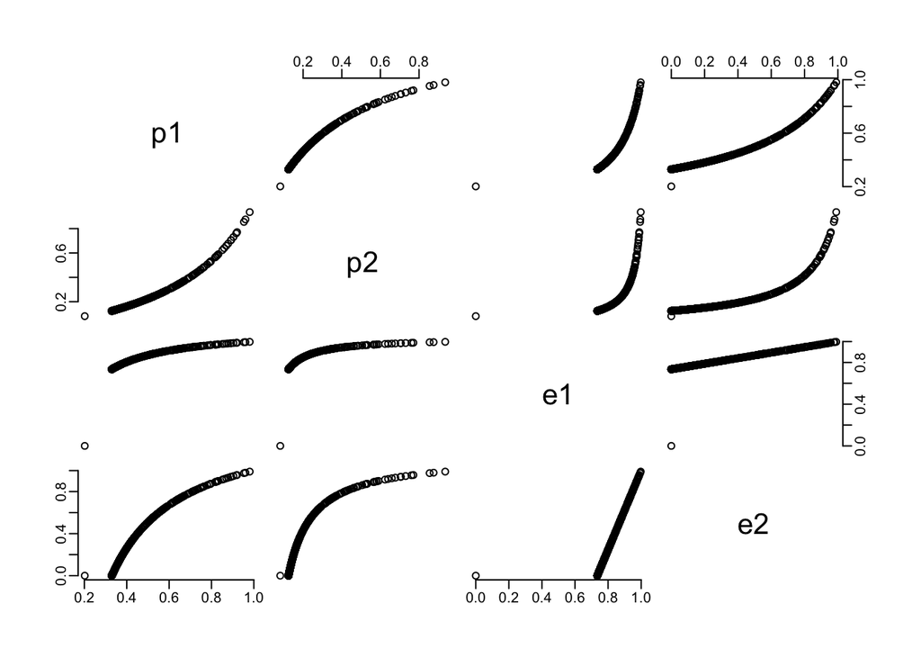

```r
pairs(estimates)
```

## Exploring hypotheses explaining these estimates

If a proportion $q$ of children get vaccinated in the private clinics instead of the public ones and thus get a first vaccine shot at 12 months instead of 9 months, then the number of children between 9 and 18 months that are vaccinated would be:

```r
             | 9 < age < 18   |   18 < age
-------------|----------------|-------------
non-chronic  | (1 - q / 3) V1 |     V2
chronic dis. | (1 - q / 3) V3 |     V4
```

It’s as if we had implicitly assumed until now that $q = 0$. Let’s explore the effect of $q$ on the estimates of $p_1$, $p_2$, $e_1$, $e_2$. The way to do is to run simulations from known values of $p_1$, $p_2$, $e_1$, $e_2$ and for various values of $q$ and then, for each value of $q$ estimate $p_1$, $p_2$, $e_1$, $e_2$ by maximum likelihood as before and compare the estimates with the true values. So, first we need a simulator:

```r
sim_vacc <- function(p, e, N, q = 0, size = 1) {
  rbinom(size, N, (1 - q / 3) * prop_vacc(p, e))
}
```

```r
p_true <- .75
e_true <- .95
N_vals <- c(526, 356, 119, 126)
V_vals <- sapply(N_vals, sim_vacc, p = p_true, e = e_true, q = 0, size = 1)

out_sim <- do.call(mlestimation,
                   c(list(p1 = .5, p2 = .5, e1 = .5, e2 = .5),
                     as.list(setNames(N_vals, c("N1", "N2", "N3", "N4"))),
                     as.list(setNames(V_vals, c("V1", "V2", "V3", "V4")))))

inverse_logit(cbind(coef(out_sim), confint(out_sim, method = "quad")))
```

```
##                      2.5 % 97.5 %
## p1 0.2754350 1.081036e-146      1
## p2 0.2927921 1.176963e-146      1
## e1 0.5418146 2.794367e-269      1
## e2 0.5704148 9.201984e-256      1
```

## Considering alternative parameterizations

Let’s try an alternative parameterisation that would assume that forces the vaccine efficacy after 1 dose only to be lower than the vaccine efficacy after 2 doses:

$$P_1 = \frac{(1 - \varepsilon e_2) p_1}{(1 - p_1) + (1 - \varepsilon e_2)
p_1}$$
$$P_2 = \frac{(1 - e_2) p_1}{(1 - p_1) + (1 - e_2) p_1}$$
$$P_3 = \frac{(1 - \varepsilon e_2) p_2}{(1 - p_2) + (1 - \varepsilon e_2)
p_2}$$
$$P_4 = \frac{(1 - e_2) p_2}{(1 - p_2) + (1 - e_2) p_2}$$

```r
mLL2 <- function(p1, p2, eps, e2) {
  p1 <- inverse_logit(p1)
  p2 <- inverse_logit(p2)
  eps <- inverse_logit(eps)
  e2 <- inverse_logit(e2)
  - sum(dbinom(c(V1, V2, V3, V4), c(N1, N2, N3, N4),
               c(((1 - eps * e2) * p1) / ((1 - p1) + (1 - eps * e2) * p1),
                 ((1 - e2) * p1) / ((1 - p1) + (1 - e2) * p1),
                 ((1 - eps * e2) * p2) / ((1 - p2) + (1 - eps * e2) * p2),
                 ((1 - e2) * p2) / ((1 - p2) + (1 - e2) * p2)), TRUE))
}
```

```r
mlestimation2 <- function(p1, p2, eps, e2, N1, N2, N3, N4, V1, V2, V3, V4, ...) {
  mle2(mLL2, as.list(logit(c(p1 = p1, p2 = p2, eps = eps, e2 = e2))),
       data = list(N1 = N1, N2 = N2, N3 = N3, N4 = N4, V1 = V1, V2 = V2, V3 = V3, V4 = V4), ...)
}
```

```r
out2 <- mlestimation2(.5, .5, .99, .9, 526, 356, 119, 126, 57, 121, 8, 12)
```

```r
inverse_logit(cbind(coef(out2), confint(out2, method = "quad")))
```

```
##                      2.5 % 97.5 %
## p1  0.22665612         NaN    NaN
## p2  0.09341221         NaN    NaN
## eps 0.99995204 7.69717e-29      1
## e2  0.13727760         NaN    NaN
```

Not conclusive. Plus: the likelihood of the first model is much higher:

```r
logLik(out)
```

```
## 'log Lik.' -12.09949 (df=4)
```

```r
logLik(out2)
```

```
## 'log Lik.' -45.29039 (df=4)
```

- vaccine coverage changing with time (epsilon)
- vaccine efficacy depends on whether the patient has chronic disease or not

$$P_1 = \frac{(1 - e_1) p_1}{(1 - p_1) + (1 - e_1) p_1}$$
$$P_2 = \frac{(1 - e_1) \varepsilon p_1}{(1 - \varepsilon p_1) + (1 -
e_1) \varepsilon p_1}$$
$$P_3 = \frac{(1 - e_2) p_2}{(1 - p_2) + (1 - e_2) p_2}$$
$$P_4 = \frac{(1 - e_2) \varepsilon p_2}{(1 - \varepsilon p_2) + (1 - e_2)
\varepsilon p_2}$$

```r
mLL2 <- function(p1, p2, e1, e2) {
  p1 <- inverse_logit(p1)
  p2 <- inverse_logit(p2)
  e1 <- inverse_logit(e1)
  e2 <- inverse_logit(e2)
  - sum(dbinom(c(V1, V2, V3, V4), c(N1, N2, N3, N4),
               c(((1 - e1) * p1) / ((1 - p1) + (1 - e1) * p1),
                 ((1 - e1) * eps * p1) / ((1 - p1) + (1 - e1) * p1),
                 ((1 - e2) * p2) / ((1 - p2) + (1 - e2) * p2),
                 ((1 - e2) * p2) / ((1 - p2) + (1 - e2) * p2)), TRUE))
}
```